# Assignment 2

Simen Ljøstad

2026-10-10

#Purpose: #Examining how wolf pup numbers are associated with moose abundance, wolf parasite load, and hunting permits.

#Data description: #The ecological setting provides context for practising multiple regression; the data are not evidence about a real ecosystem. The predictor variables included in the dataset are the number of adult moose in the park (ADULTS), the number of moose calves born (CALVES), the average blood helminth load (WORMS) of trapped wolves (determined using blood samples from randomly selected wolves every year), and the number of moose hunting permits (PERMITS) issued by the park to human hunters. #Source: Made up data for a practical excerise

#Libraries ####

```r
library(car)
library(GGally)
library(performance)
library(tidyverse)
```

#Load dataset

```r
df_WOLFPUPS<-read_csv("WOLFPUPS.csv")
```

#Data quality control ####

```r
str(df_WOLFPUPS)
```

```
## spc_tbl_ [45 × 6] (S3: spec_tbl_df/tbl_df/tbl/data.frame)
##  $ YEAR   : num [1:45] 1955 1956 1957 1958 1959 ...
##  $ ADULTS : num [1:45] 559 287 459 599 765 340 377 506 530 517 ...
##  $ CALVES : num [1:45] 122 67 98 120 158 72 105 106 109 109 ...
##  $ WORMS  : num [1:45] 0.518 0.95 0.537 1.032 0.991 ...
##  $ PERMITS: num [1:45] 24 21 33 35 28 25 18 18 17 22 ...
##  $ PUPS   : num [1:45] 13 6 13 6 10 5 13 7 5 12 ...
##  - attr(*, "spec")=
##   .. cols(
##   ..   YEAR = col_double(),
##   ..   ADULTS = col_double(),
##   ..   CALVES = col_double(),
##   ..   WORMS = col_double(),
##   ..   PERMITS = col_double(),
##   ..   PUPS = col_double()
##   .. )
##  - attr(*, "problems")=<pointer: 0x0000027071e8d500>
```

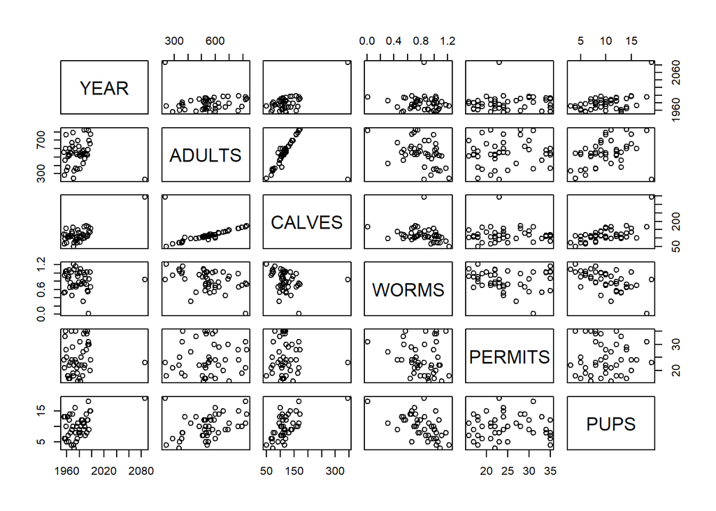

```r
plot(df_WOLFPUPS)
```

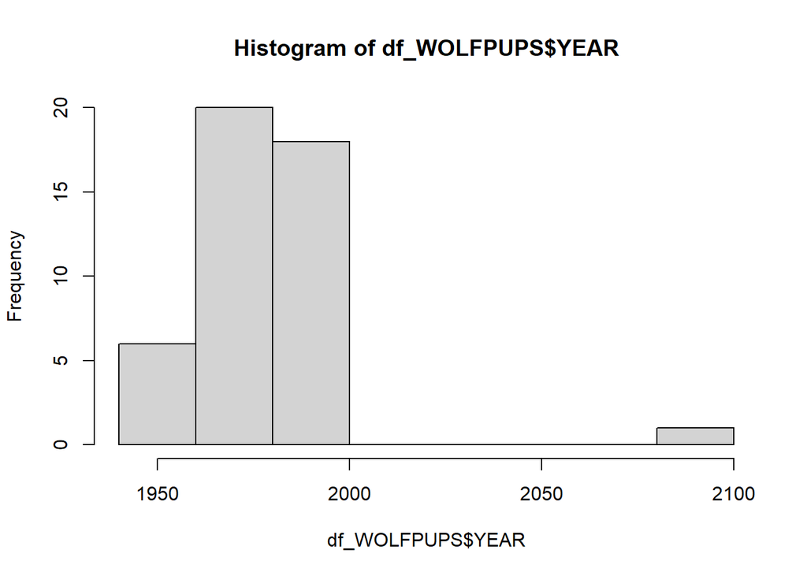

```r
#Histograms for each predictor
hist(df_WOLFPUPS$YEAR) #Datapoint from 2086??
```

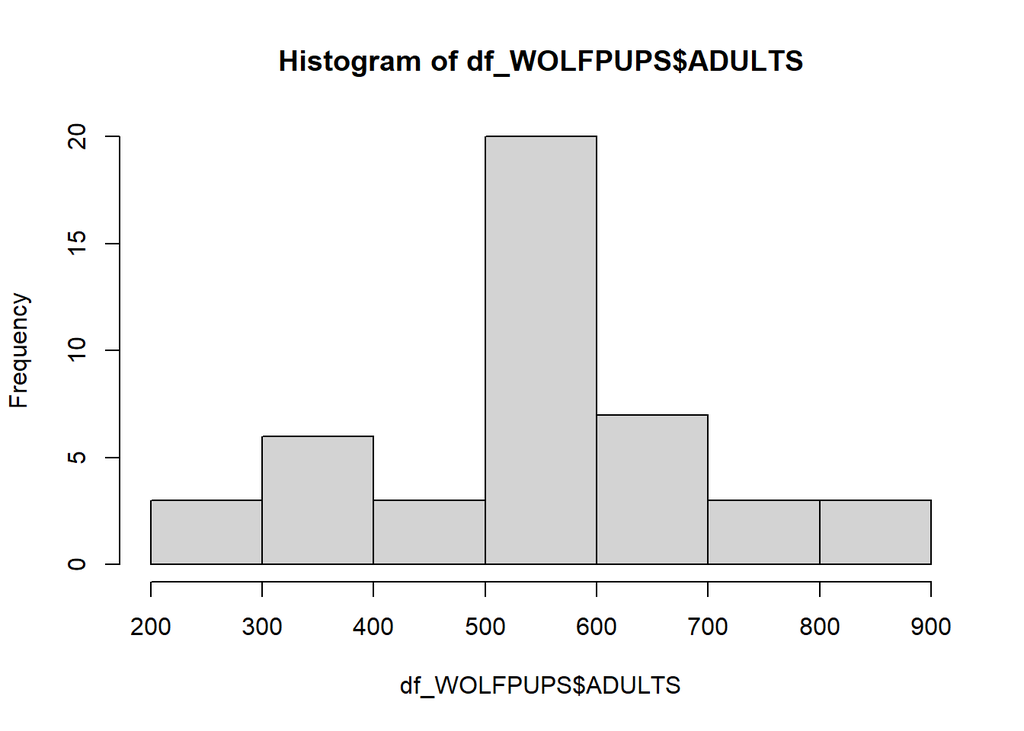

```r
hist(df_WOLFPUPS$ADULTS)
```

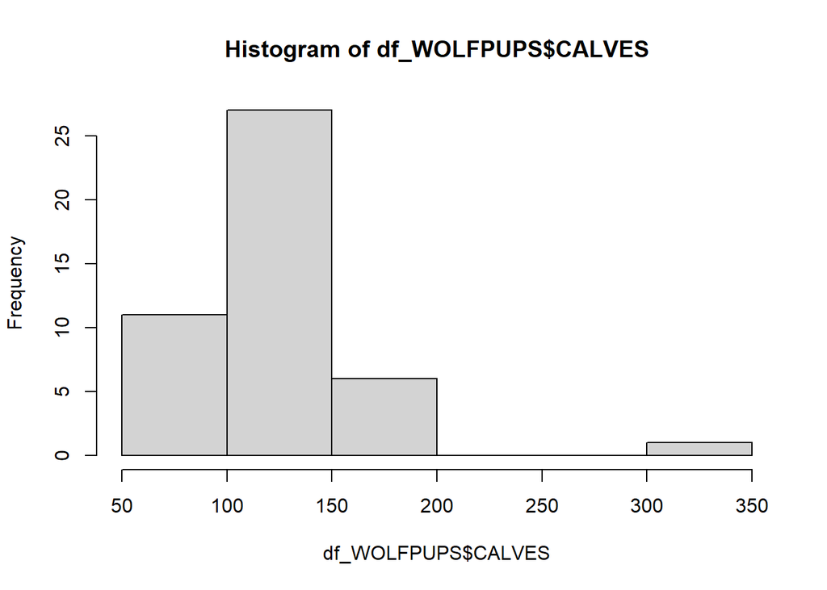

```r
hist(df_WOLFPUPS$CALVES)
```

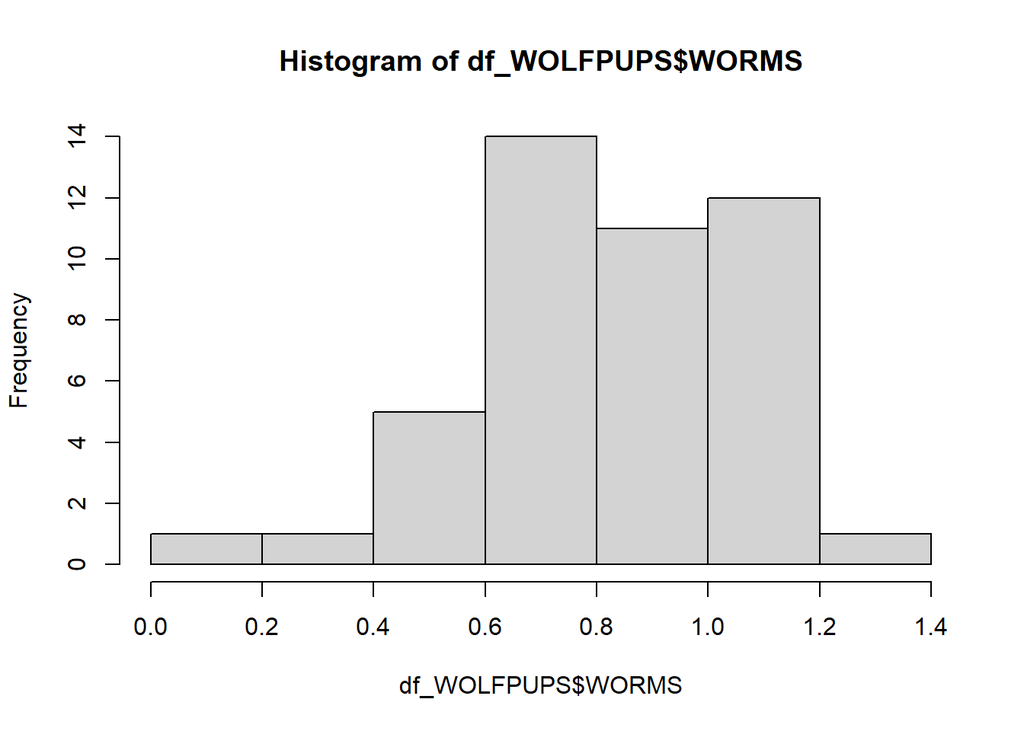

```r
hist(df_WOLFPUPS$WORMS)
```

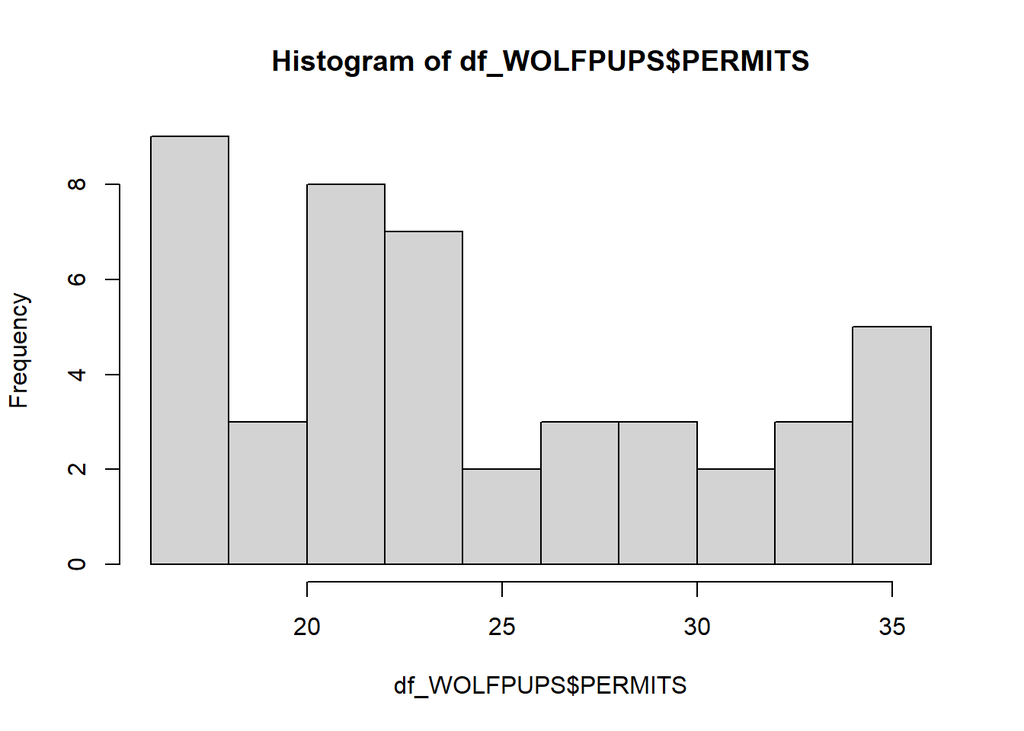

```r
hist(df_WOLFPUPS$PERMITS)
```

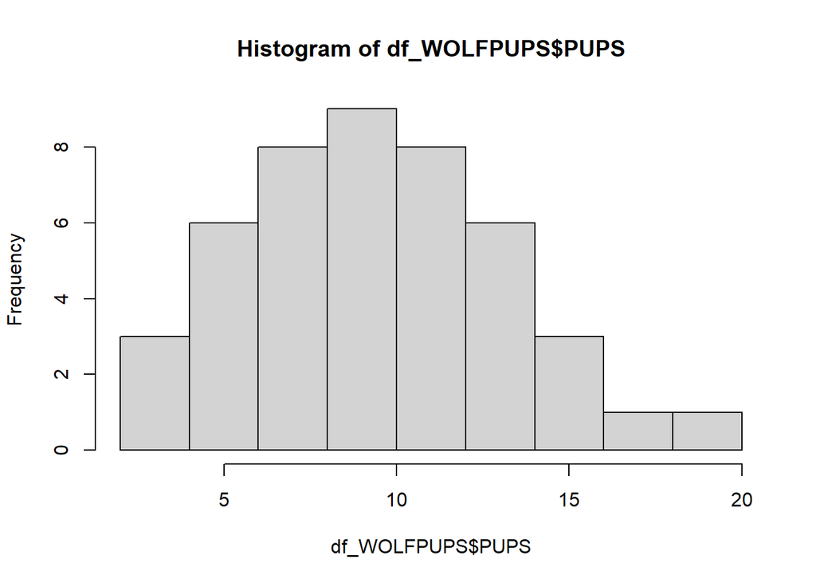

```r
hist(df_WOLFPUPS$PUPS)
```

```r
df_WOLFPUPS.corr <- df_WOLFPUPS%>%
  filter(YEAR<2026)
```

#Checking corrected data

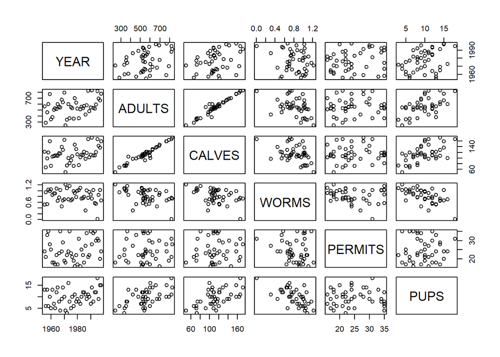

```r
plot(df_WOLFPUPS.corr)
```

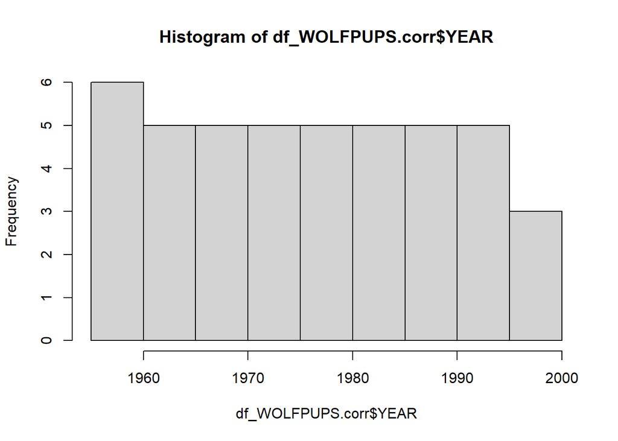

```r
hist(df_WOLFPUPS.corr$YEAR)
```

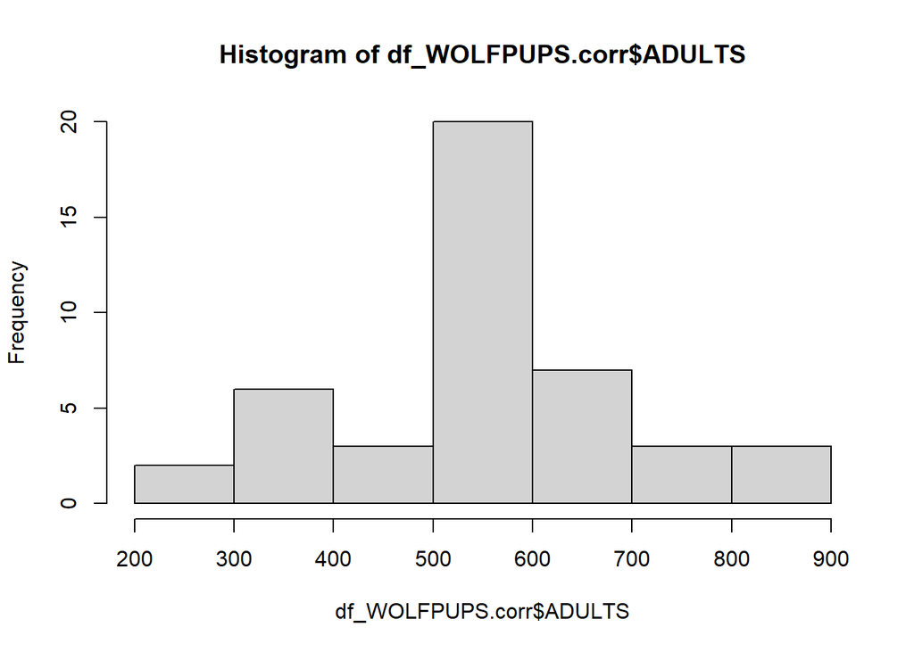

```r
hist(df_WOLFPUPS.corr$ADULTS)
```

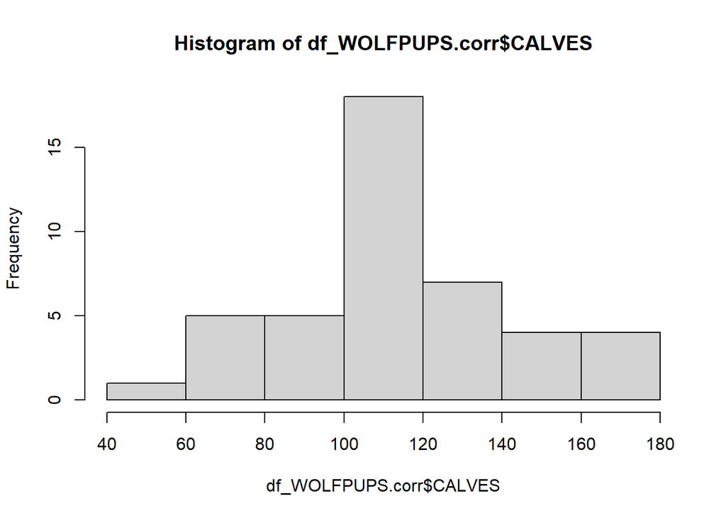

```r
hist(df_WOLFPUPS.corr$CALVES)
```

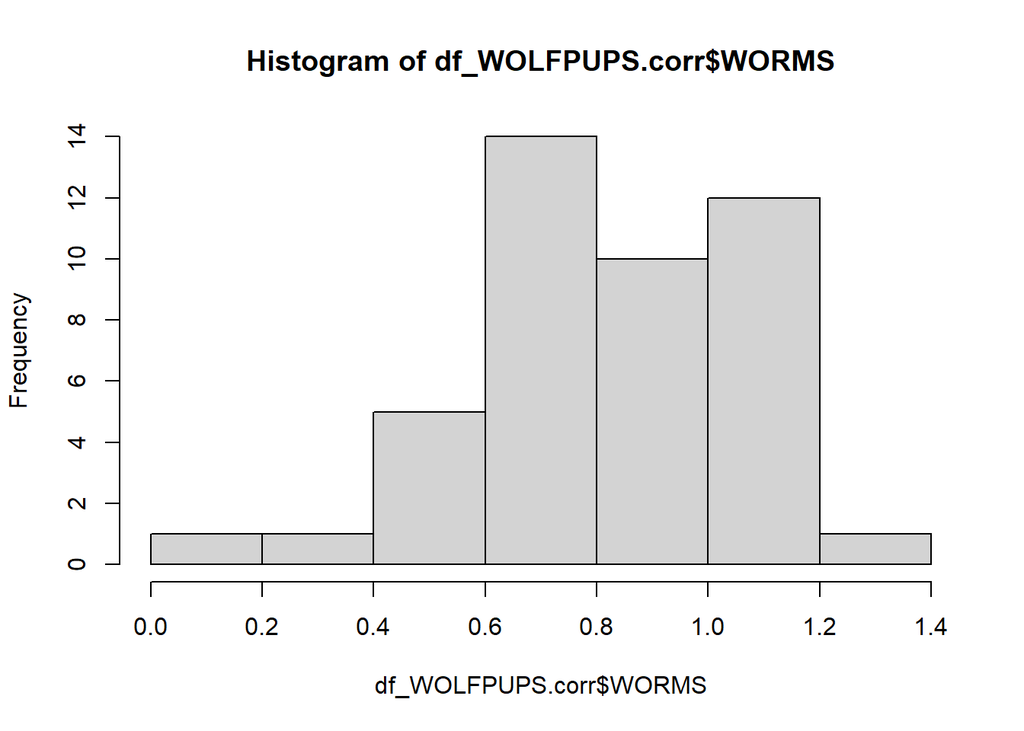

```r
hist(df_WOLFPUPS.corr$WORMS)
```

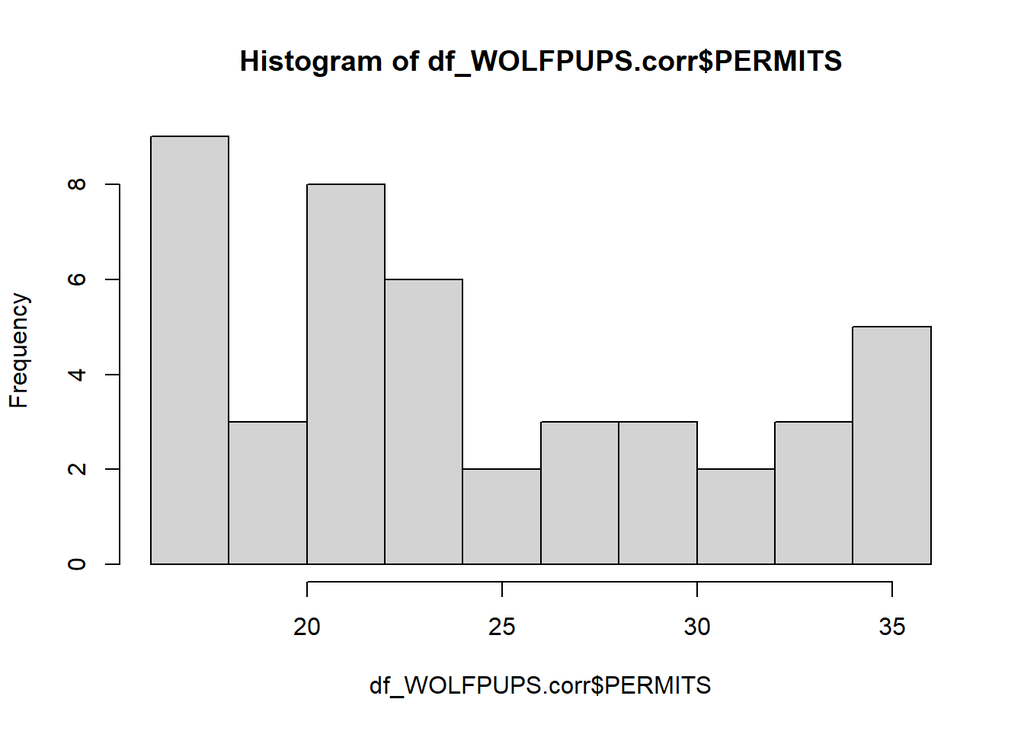

```r
hist(df_WOLFPUPS.corr$PERMITS)
```

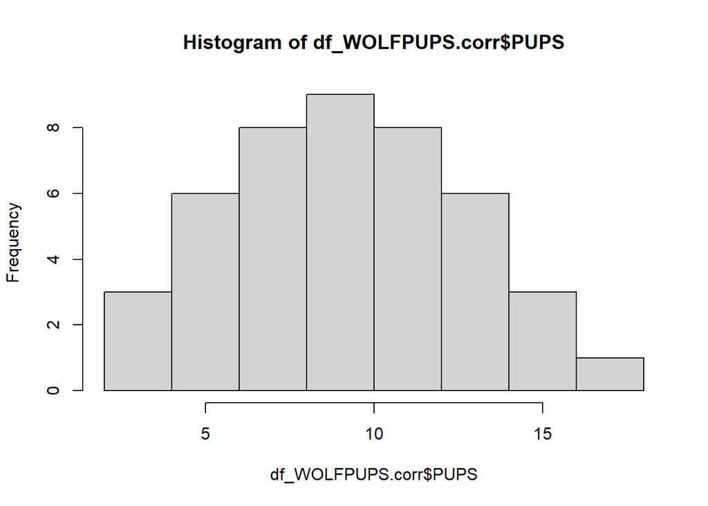

```r
hist(df_WOLFPUPS.corr$PUPS)
```

#Checking for colinearity

[output not shown]

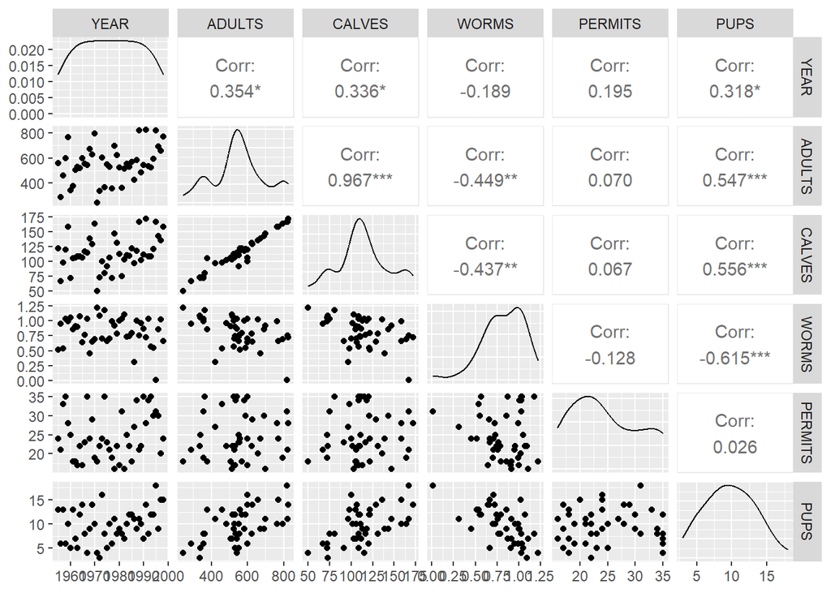

```r
ggpairs(df_WOLFPUPS.corr)
```

#Constructing a model and model diagnostics ####

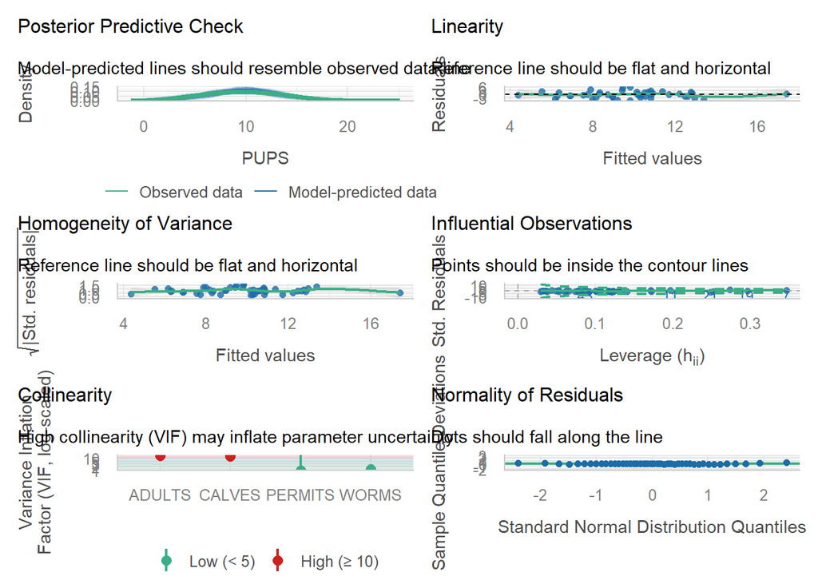

```r
MOD.1<-lm(PUPS~ADULTS+
            CALVES+
            WORMS+
            PERMITS,
                  data=df_WOLFPUPS.corr)

check_model(MOD.1) #Adults and calves have high colinearity
```

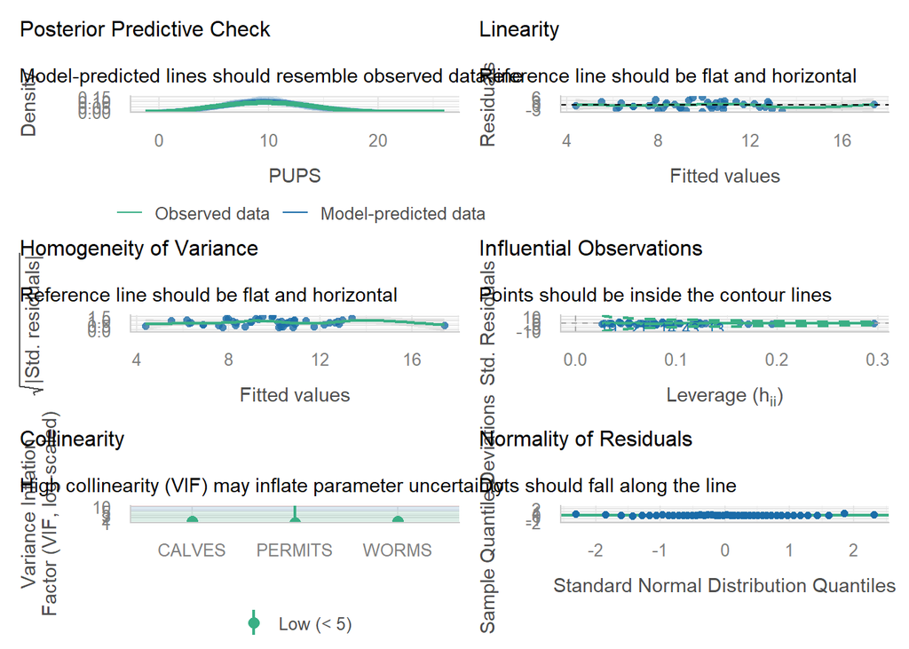

```r
MOD.2 <- update(MOD.1,~.- ADULTS)
check_model(MOD.2) #Colinearity is acceptable now
```

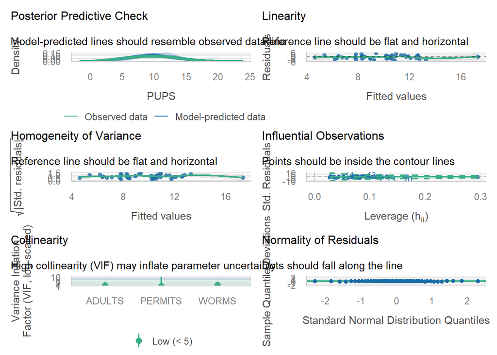

```r
#Test if there is a difference in removing calves instead?
MOD.3 <- update(MOD.1,~.- CALVES)
check_model(MOD.3) #Not much of a difference
```

#Model simplification ####

```r
summary(MOD.2) #Permits have the lowest effect
```

```
##
## Call:
## lm(formula = PUPS ~ CALVES + WORMS + PERMITS, data = df_WOLFPUPS.corr)
##
## Residuals:
##    Min     1Q Median     3Q    Max
## -4.896 -1.713 -0.001  1.650  6.088
##
## Coefficients:
##             Estimate Std. Error t value Pr(>|t|)
## (Intercept) 11.16643    3.34793   3.335  0.00185 **
## CALVES       0.04406    0.01566   2.813  0.00757 **
## WORMS       -6.87087    1.86778  -3.679  0.00069 ***
## PERMITS     -0.03349    0.06587  -0.508  0.61400
## ---
## Signif. codes:  0 '***' 0.001 '**' 0.01 '*' 0.05 '.' 0.1 ' ' 1
##
## Residual standard error: 2.641 on 40 degrees of freedom
## Multiple R-squared:  0.4835, Adjusted R-squared:  0.4448
## F-statistic: 12.48 on 3 and 40 DF,  p-value: 6.69e-06
```

```r
MOD.4 <- update(MOD.2,~.- PERMITS)
anova(MOD.2, MOD.4) #Test if new model is significantly worse
```

```
## Analysis of Variance Table
##
## Model 1: PUPS ~ CALVES + WORMS + PERMITS
## Model 2: PUPS ~ CALVES + WORMS
##   Res.Df    RSS Df Sum of Sq      F Pr(>F)
## 1     40 279.05
## 2     41 280.85 -1   -1.8028 0.2584  0.614
```

```r
summary(MOD.4)
```

```
##
## Call:
## lm(formula = PUPS ~ CALVES + WORMS, data = df_WOLFPUPS.corr)
##
## Residuals:
##     Min      1Q  Median      3Q     Max
## -4.8239 -1.7410 -0.1149  1.7320  6.1227
##
## Coefficients:
##             Estimate Std. Error t value Pr(>|t|)
## (Intercept) 10.26475    2.81364   3.648 0.000739 ***
## CALVES       0.04396    0.01552   2.833 0.007127 **
## WORMS       -6.76661    1.83962  -3.678 0.000676 ***
## ---
## Signif. codes:  0 '***' 0.001 '**' 0.01 '*' 0.05 '.' 0.1 ' ' 1
##
## Residual standard error: 2.617 on 41 degrees of freedom
## Multiple R-squared:  0.4802, Adjusted R-squared:  0.4548
## F-statistic: 18.93 on 2 and 41 DF,  p-value: 1.498e-06
```

```r
#Test to try to remove the next one
MOD.5 <- update(MOD.4,~.- CALVES)
anova(MOD.4, MOD.5) #High F-value, so Calves should not be removed
```

```
## Analysis of Variance Table
##
## Model 1: PUPS ~ CALVES + WORMS
## Model 2: PUPS ~ WORMS
##   Res.Df    RSS Df Sum of Sq     F   Pr(>F)
## 1     41 280.85
## 2     42 335.81 -1   -54.964 8.024 0.007127 **
## ---
## Signif. codes:  0 '***' 0.001 '**' 0.01 '*' 0.05 '.' 0.1 ' ' 1
```

#Centering and scaling ####

```r
summary(MOD.4)
```

```
##
## Call:
## lm(formula = PUPS ~ CALVES + WORMS, data = df_WOLFPUPS.corr)
##
## Residuals:
##     Min      1Q  Median      3Q     Max
## -4.8239 -1.7410 -0.1149  1.7320  6.1227
##
## Coefficients:
##             Estimate Std. Error t value Pr(>|t|)
## (Intercept) 10.26475    2.81364   3.648 0.000739 ***
## CALVES       0.04396    0.01552   2.833 0.007127 **
## WORMS       -6.76661    1.83962  -3.678 0.000676 ***
## ---
## Signif. codes:  0 '***' 0.001 '**' 0.01 '*' 0.05 '.' 0.1 ' ' 1
##
## Residual standard error: 2.617 on 41 degrees of freedom
## Multiple R-squared:  0.4802, Adjusted R-squared:  0.4548
## F-statistic: 18.93 on 2 and 41 DF,  p-value: 1.498e-06
```

```r
MOD.4s <- lm(PUPS ~ scale(CALVES) + scale(WORMS),
             data = df_WOLFPUPS.corr)
summary(MOD.4s) #Worms is the higher predictor
```

```
##
## Call:
## lm(formula = PUPS ~ scale(CALVES) + scale(WORMS), data = df_WOLFPUPS.corr)
##
## Residuals:
##     Min      1Q  Median      3Q     Max
## -4.8239 -1.7410 -0.1149  1.7320  6.1227
##
## Coefficients:
##               Estimate Std. Error t value Pr(>|t|)
## (Intercept)     9.7500     0.3946  24.711  < 2e-16 ***
## scale(CALVES)   1.2567     0.4436   2.833 0.007127 **
## scale(WORMS)   -1.6318     0.4436  -3.678 0.000676 ***
## ---
## Signif. codes:  0 '***' 0.001 '**' 0.01 '*' 0.05 '.' 0.1 ' ' 1
##
## Residual standard error: 2.617 on 41 degrees of freedom
## Multiple R-squared:  0.4802, Adjusted R-squared:  0.4548
## F-statistic: 18.93 on 2 and 41 DF,  p-value: 1.498e-06
```

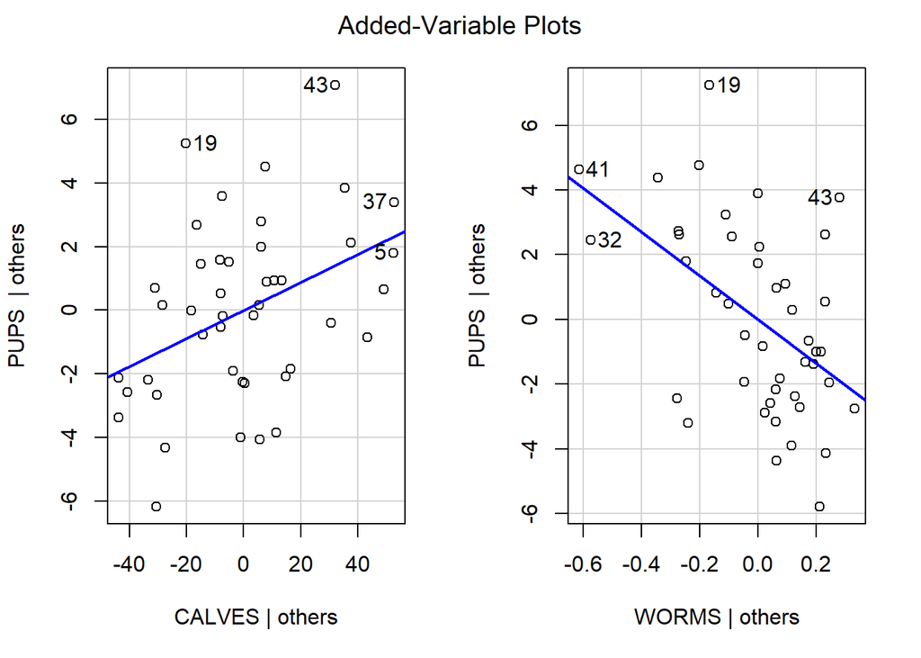

```r
#Inspecting added variable plots
avPlots(MOD.4)
```

#Visualizing Partial Effects ####

```r
summary(df_WOLFPUPS.corr)
```

```
##       YEAR          ADULTS          CALVES          WORMS            PERMITS
##  Min.   :1955   Min.   :243.0   Min.   : 50.0   Min.   :0.01152   Min.   :16.00
##  1st Qu.:1966   1st Qu.:500.0   1st Qu.:101.5   1st Qu.:0.68969   1st Qu.:19.75
##  Median :1976   Median :546.0   Median :110.5   Median :0.85728   Median :23.50
##  Mean   :1976   Mean   :553.2   Mean   :114.4   Mean   :0.81934   Mean   :24.73
##  3rd Qu.:1987   3rd Qu.:624.8   3rd Qu.:129.5   3rd Qu.:1.01026   3rd Qu.:30.00
##  Max.   :1998   Max.   :826.0   Max.   :172.0   Max.   :1.21979   Max.   :35.00
##       PUPS
##  Min.   : 3.00
##  1st Qu.: 7.00
##  Median :10.00
##  Mean   : 9.75
##  3rd Qu.:12.00
##  Max.   :18.00
```

```r
NEWPUPS_varWORMS <- crossing(WORMS = seq(0.01,1.22,
                                         length = 100),
                             CALVES = mean(df_WOLFPUPS.corr$CALVES),
                             PERMITS = mean(df_WOLFPUPS.corr$PERMITS))
NEWPUPS_varWORMS
```

```
## # A tibble: 100 × 3
##     WORMS CALVES PERMITS
##     <dbl>  <dbl>   <dbl>
##  1 0.01     114.    24.7
##  2 0.0222   114.    24.7
##  3 0.0344   114.    24.7
##  4 0.0467   114.    24.7
##  5 0.0589   114.    24.7
##  6 0.0711   114.    24.7
##  7 0.0833   114.    24.7
##  8 0.0956   114.    24.7
##  9 0.108    114.    24.7
## 10 0.12     114.    24.7
## # ℹ 90 more rows
```

```r
NEWYUSINGWORMS <- predict(MOD.2,
                          newdata = NEWPUPS_varWORMS,
                          int = "c")
varWORMS_PREDS <- bind_cols(NEWPUPS_varWORMS,
                            as_tibble(NEWYUSINGWORMS))
```

#Plotting with ggplot ####

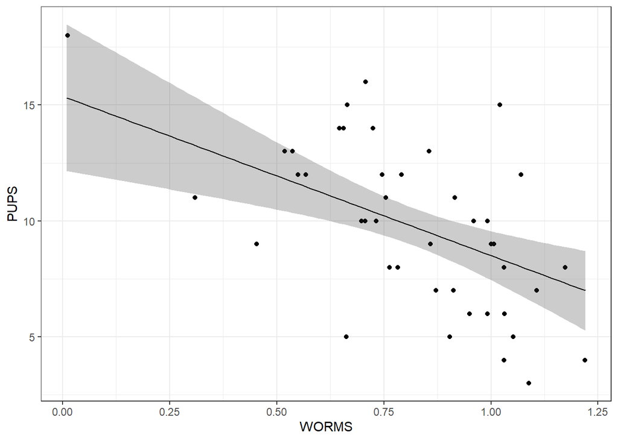

```r
ggplot(varWORMS_PREDS,
       aes(x = WORMS, y = fit)) +
  geom_line() +
  geom_point(data=df_WOLFPUPS.corr, #Adding points from the original dataset
             aes(x = WORMS, y= PUPS)) +
  geom_ribbon(aes(ymin = lwr,
                  ymax = upr),
              alpha = 0.25) + # this argument makes the CI transparent
  labs(x = "WORMS",
       y = expression("PUPS")) +
  theme_bw()
```

#Limitation: Wolf pup numbers may be affected by other predictors not studied as well.